# Unifying data

# Exploratory analysis

```python
# Gettings only columns of interest
cols = ['order_id', 'on_demand', 'total_minutes', 'seniority', 'found_rate', 'picking_speed',
       'accepted_rate', 'rating', 'size_kg', 'size_un', 'quantity_un', 'quantity_kg',
       'total_size', 'total_quantity', 'distance', 'day_of_week', 'hour_of_day', 'rush_hour',
       'total_products_found', 'avg_time_picking', 'top_store', 'branch_proportion', 'total_shopper_day',
       'avg_hour_shopper_order', 'avg_hour_branch_order', 'sin_time', 'cos_time']

exploratory = df[cols].set_index('order_id')
#separating type of variables
cat_cols = ['on_demand', 'seniority', 'day_of_week', 'hour_of_day', 'rush_hour',
        'top_store']
num_cols = [x for x in cols if x not in cat_cols + ['order_id', 'total_minutes']]
```

```python
def plot_cat(df, col1, col2 = 'total_minutes'):
    """
    Function defined to plot caregorical variables to be related to the target
    Param:
    df: DataFrame
    col1, col2: column in DF
    """
    f, ax = plt.subplots(figsize=(9,6))
    sns.histplot(data=df, x=col2, hue = col1, ax=ax)
    ax.set_title(f"Histogram of total_minutes by {col1}")
    ax.figure

    f, ax = plt.subplots(figsize=(9,6))
    sns.boxplot(data=df, y=col2, x = col1, ax=ax)
    ax.set_title(f"Box PLot of total_minutes by {col1}")
    ax.set_xticklabels(ax.get_xticklabels(), rotation=45, ha='right')
    ax.figure

def plot_numeric(df, col1, col2 = 'total_minutes', hue = None, kind = 'scatter', xlim = None):
    """
    Function defined to plot numerical variables to be related to the target
    Param:
    df: DataFrame
    col1, col2: column in DF
    """
    #plotting only 0.05 to 0.95 centile to rmeove "outliers" in graphs to better visualizations
    g = sns.jointplot(data=df, x=col1, y=col2, hue = hue, kind = kind, height=8, ratio=2,
                      xlim=xlim)
```

## Total Minutes

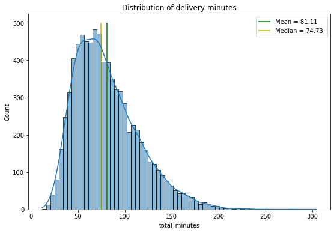

```python
f, ax = plt.subplots(figsize=(9,6))
sns.histplot(data=exploratory, x='total_minutes', kde=True ,ax=ax)
plt.vlines(x=exploratory['total_minutes'].mean(), ymin=0,ymax= 500, color='g',
           label=f"Mean = {exploratory['total_minutes'].mean():.2f} ")
plt.vlines(x=exploratory['total_minutes'].median(), ymin=0,ymax= 500, color='y',
           label=f"Median = {exploratory['total_minutes'].median():.2f} ")
plt.title('Distribution of delivery minutes')
plt.legend()
```

## On_demand with total_minutes

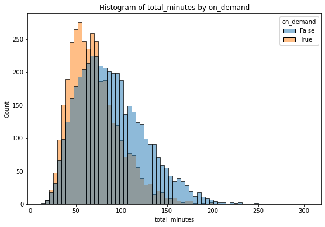

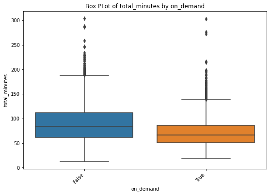

```python
plot_cat(exploratory, 'on_demand')
```

```python
minutes_mean_false = f"{exploratory.loc[exploratory['on_demand']==False, 'total_minutes'].mean():.2f}"
minutes_mean_true = f"{exploratory.loc[exploratory['on_demand']==True, 'total_minutes'].mean():.2f}"
```

## Seniority to total_minutes

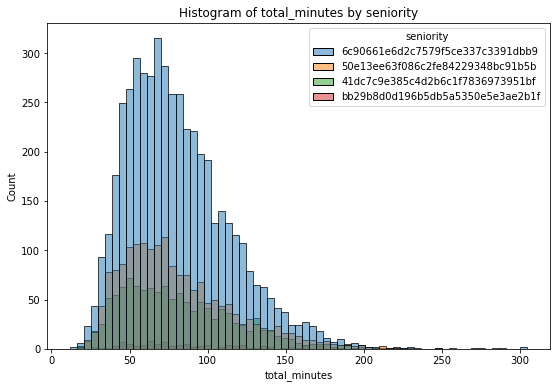

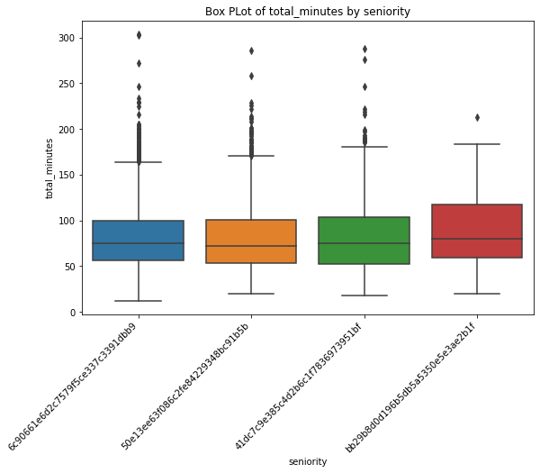

```python
plot_cat(exploratory, 'seniority')
```

## Day of Week

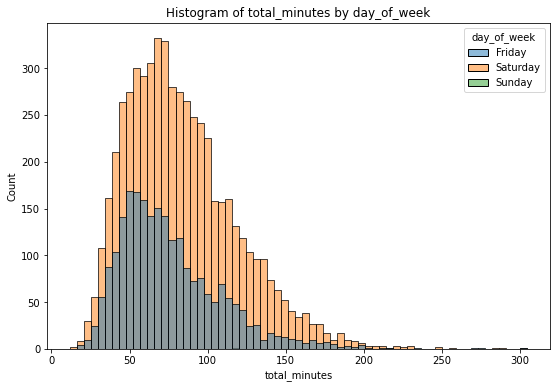

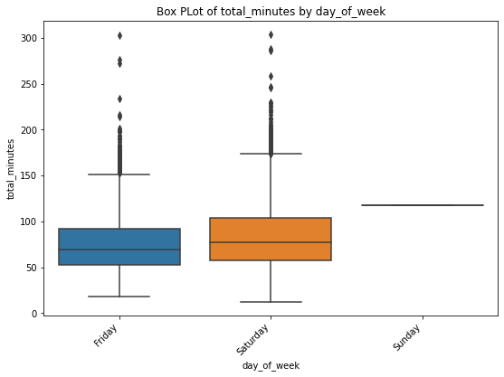

```python
plot_cat(exploratory, 'day_of_week')
```

## Hour of day

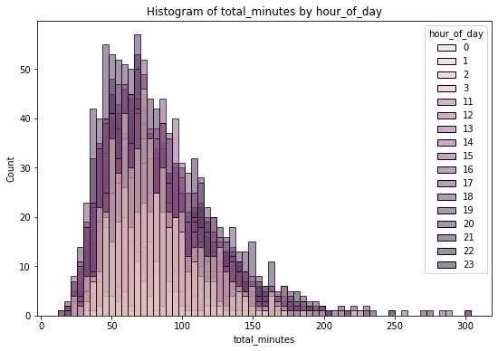

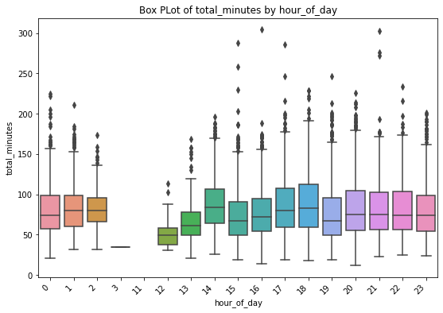

```python
plot_cat(exploratory, 'hour_of_day')
```

There doesn't apper to be much difference between the total minutes of delivery to the hour of the day, although noon looks a little lower. Maybe noon has orders based on lunch (on demand) and other kinds (not on demand)? Let's investigate how it relates with this variable

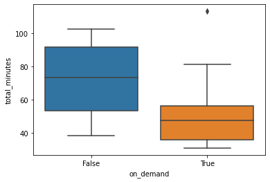

```python
sns.boxplot(data=exploratory[exploratory['hour_of_day']==12], y='total_minutes', x='on_demand')
```

A big difference appears on the median value of total_minutes wheter the order is on-demand or not in the Noon time (~50 minutes to on demand, to ~75 minutes for not on demand)

## Rush hour

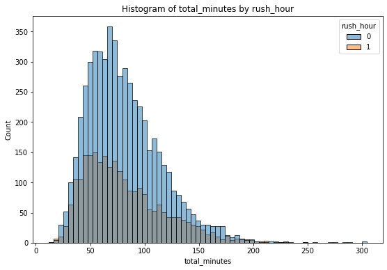

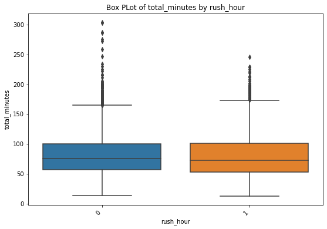

```python
plot_cat(exploratory, 'rush_hour')
```

There isnt a big difference to the rush hour times

## Top Store

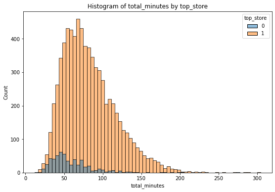

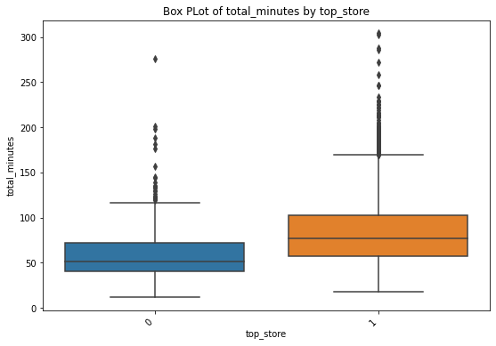

```python
plot_cat(exploratory, 'top_store')
```

## Found rate

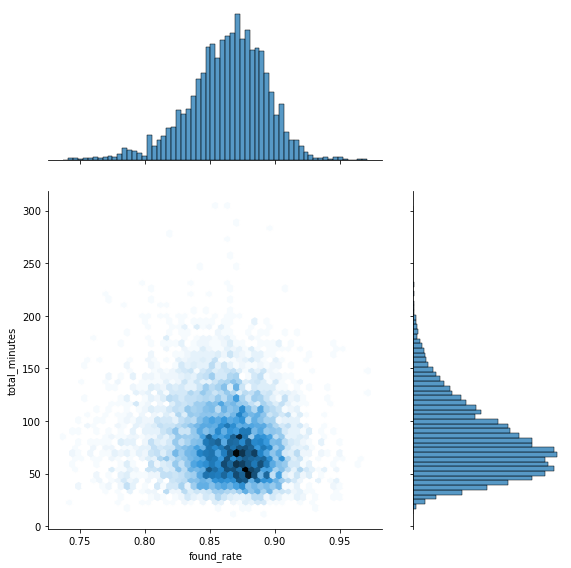

```python
plot_numeric(exploratory, 'found_rate', kind='hex')
```

## Picking Speed

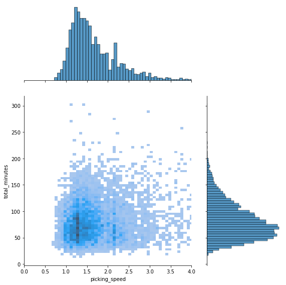

```python
plot_numeric(exploratory, 'picking_speed', kind='hist', xlim=(0,4))
```

## Accepted rate

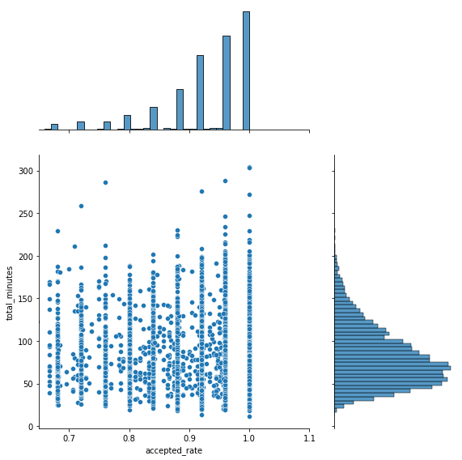

```python
plot_numeric(exploratory, 'accepted_rate', kind='scatter', xlim=(0.65,1.1))
```

## Rating

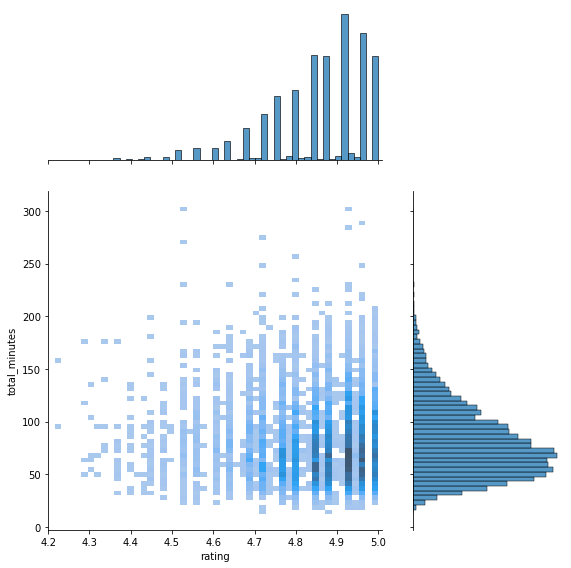

```python
plot_numeric(exploratory, 'rating', kind='hist', xlim= (4.2,5.01))
```

## Total of different products

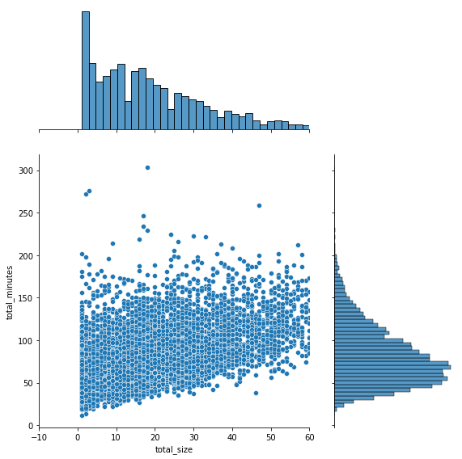

```python
plot_numeric(exploratory, 'total_size', kind='scatter', xlim=(-10, 60))
```

## Total quantity of products

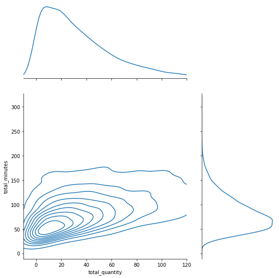

```python
plot_numeric(exploratory, 'total_quantity', kind='kde', xlim=(-10,120))
```

## Distance

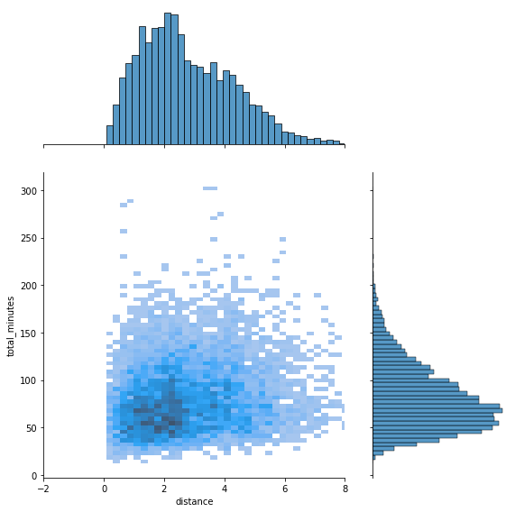

```python
plot_numeric(exploratory, 'distance', kind='hist', xlim=(-2,8))
```

## Total products found

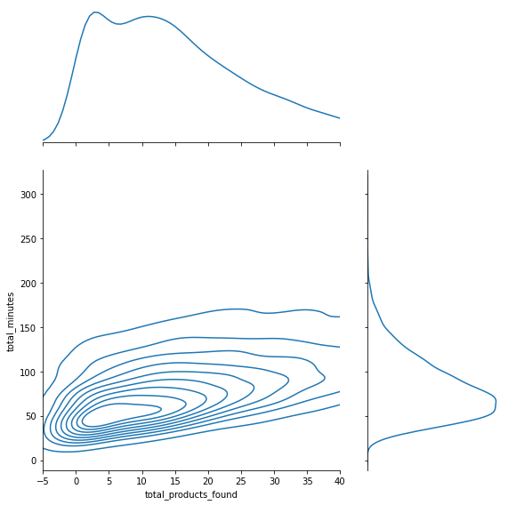

```python
plot_numeric(exploratory, 'total_products_found', kind='kde', xlim=(-5,40))
```

## Average time picking

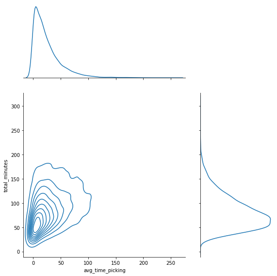

```python
plot_numeric(exploratory, 'avg_time_picking', kind='kde')
```

## Branch proportion

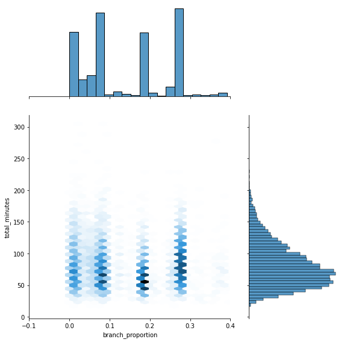

```python
plot_numeric(exploratory, 'branch_proportion', kind='hex', xlim=(-0.1,0.4))
```

## Total orders shoppers made in he day

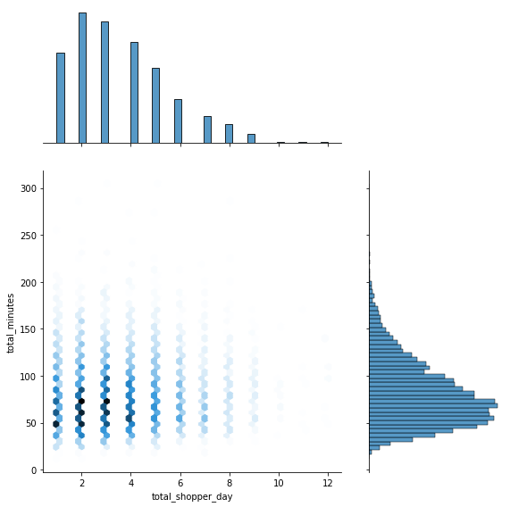

```python
plot_numeric(exploratory, 'total_shopper_day', kind='hex')
```